# Quantifiying overlap in the composition of categories

Michael Jahn

16 Oktober, 2024

### Background

Often in biology we encounter situations where one gene maps to different pathways, or different pathways to the same gene. I other words, gene-pathway relationships are member-category relationships that can have a large degree of redundancy or overlap. Some pathways/categories might be highly similar when comparing the list of their members. It is often useful to know the degree of overlap between pathways/categories, and optionally reduce the list of pathways to leave only one representative instead of multiple highly similar ones.

This document walks through one example where we determine overlap between pathways of the [subtiwiki pathway categories](http://www.subtiwiki.uni-goettingen.de/v3/category/ for the bacterium *Bacillus subtilis*.

If you find a built-in function in an R package that will do this automatically, please [leave a message](https://github.com/MPUSP/bioinfo-code-chunks/issues).

### Libraries and test data

- load required libraries

```r
suppressPackageStartupMessages({
  library(tidyverse)
})
```

- import category test data (from subtiwiki)

```r
df_subtiwiki <- read_csv("../data/geneCategories-2022-09-02.csv",
  name_repair = function(x) str_replace_all(x, " ", "_"),
  show_col_types = FALSE)

head(df_subtiwiki)
```

| category_id | category | gene_locus | gene_name |
| --- | --- | --- | --- |
| SW.3.1.1 | DNA replication | BSU_00010 | NA |
| SW.6.1 | Essential genes | BSU_00010 | NA |
| SW.3.1.1 | DNA replication | BSU_00020 | NA |
| SW.6.1 | Essential genes | BSU_00020 | NA |
| SW.3.1.5.7 | Mismatch repair (MMR) | BSU_00020 | NA |
| SW.3.3.1.6 | Ribosome assembly | BSU_00030 | NA |

### Calculate overlap

- in order to estimate overlap, the data is transformed into a 2-dimensional matrix with pathways on rows, genes on columns
- the matrix is a binary matrix filled with membership relations (1 - member, 0 - no member)

```r
mat_categories <- df_subtiwiki %>%
  mutate(category = str_sub(category, 1, 25)) %>%
  select(category, gene_locus) %>%
  distinct() %>%
  mutate(dummy = 1) %>%
  pivot_wider(id_cols = category, names_from = gene_locus,
    values_from = dummy, values_fill = 0) %>%
  column_to_rownames("category") %>%
  as.matrix

mat_categories[1:5, 1:5]
```

```
                      BSU_00010 BSU_00020 BSU_00030 BSU_00040 BSU_00050
DNA replication               1         1         0         0         0
Essential genes               1         1         0         0         0
Mismatch repair (MMR)         0         1         0         0         0
Ribosome assembly             0         0         1         0         0
Cell shape                    0         0         1         0         0
```

- reduce result to 50 first categories
- the binary matrix is clustered by similarity and plotted as dendrogram

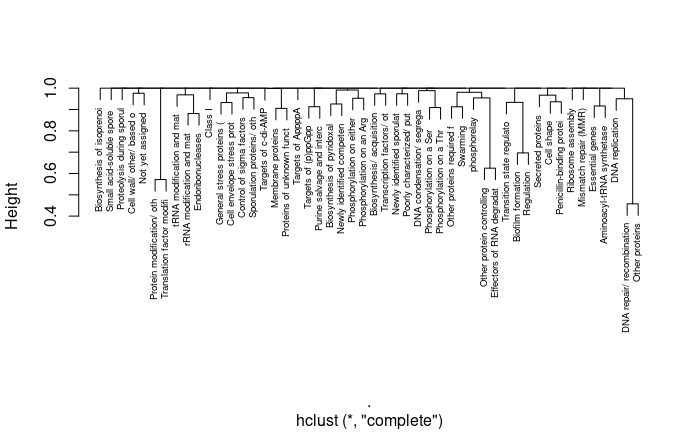

```r
hclust_cat <- dist(mat_categories[1:50, ], method = "binary") %>%
  hclust(method = "complete")

plot(hclust_cat, cex = 0.6, main = NA)
```

- the binary distance metric shows that, for example, two pathways with distance 0.5 have 50% of their member genes in common
- we can find these by “cutting” the dendrogram at height = 0.5

```r
cutree(hclust_cat, h = 0.5) %>%
  {duplicated(.) | rev(duplicated(rev(.)))} %>%
  which %>% hclust_cat$labels[.]
```

```
[1] "DNA repair/ recombination" "Other proteins"
```

- we can also calculate the distance metric directly and find similar pathways by filtering
- note: the heatmap shows only every second label due to size restrictions

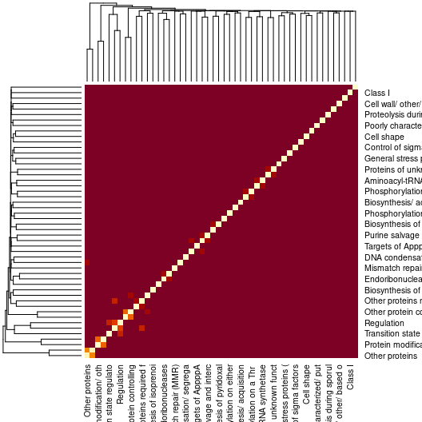

```r
dist(mat_categories[1:50, ], method = "binary") %>%
  as.matrix %>%
  heatmap
```

- filter categories (rows) where dist metric falls below a threshold of 0.5
- same result as dendrogram

```r
dist(mat_categories[1:50, ], method = "binary") %>%
  as.matrix %>%
  as.data.frame %>%
  mutate(across(everything(), ~ replace(.x, .x == 0, NA))) %>%
  filter(if_any(everything(), ~ .x < 0.5))
```

|  | DNA replication | Essential genes | Mismatch repair (MMR) | Ribosome assembly | Cell shape | DNA repair/ recombination | Other proteins | Biofilm formation | Other proteins required f | DNA condensation/ segrega | Phosphorylation on a Ser | Newly identified sporulat | Biosynthesis/ acquisition | Phosphorylation on either | Targets of (p)ppGpp | Targets of AppppA | Penicillin-binding protei | Membrane proteins | Secreted proteins | Swarming | Biosynthesis of pyridoxal | Phosphorylation on an Arg | Newly identified competen | Aminoacyl-tRNA synthetase | Purine salvage and interc | General stress proteins ( | Class I | Poorly characterized/ put | tRNA modification and mat | … |
| --- | --- | --- | --- | --- | --- | --- | --- | --- | --- | --- | --- | --- | --- | --- | --- | --- | --- | --- | --- | --- | --- | --- | --- | --- | --- | --- | --- | --- | --- | --- |
| DNA repair/ recombination | 0.9504950 | 0.9939394 | 0.9736842 | 1 | 1 | NA | 0.4578313 | 1 | 1 | 1 | 0.9929577 | 0.9960474 | 1 | 1 | 1 | 1 | 1 | 1 | 1 | 0.9942857 | 1 | 0.9783784 | 1.0000000 | 1 | 1 | 0.9915254 | 1 | 1 | 0.9919355 | … |
| Other proteins | 0.9113924 | 0.9935484 | 1.0000000 | 1 | 1 | 0.4578313 | NA | 1 | 1 | 1 | 0.9918033 | 1.0000000 | 1 | 1 | 1 | 1 | 1 | 1 | 1 | 0.9870130 | 1 | 0.9757576 | 0.9873418 | 1 | 1 | 0.9953917 | 1 | 1 | 0.9903846 | … |